# 05. Matplotlib

## Seaborn

- O *seaborn* é um pacote que utiliza o *matplotlib* e simplifica como criar algumas visualizações

```python
import seaborn as sns
```

```python
tips = pd.read_csv('datasets/tips.csv')
tips.head(3)
```

|  | total_bill | tip | sex | smoker | day | time | size |
| --- | --- | --- | --- | --- | --- | --- | --- |
| 0 | 16.99 | 1.01 | Female | No | Sun | Dinner | 2 |
| 1 | 10.34 | 1.66 | Male | No | Sun | Dinner | 3 |
| 2 | 21.01 | 3.50 | Male | No | Sun | Dinner | 3 |

- Vamos gerar uma plotagem de barras que apresente o percentual de gorgetas por dia usando o seaborn

```python
party_counts = pd.crosstab(tips['day'], tips['size'])
party_counts
```

| size day | 1 | 2 | 3 | 4 | 5 | 6 |
| --- | --- | --- | --- | --- | --- | --- |
| Fri | 1 | 16 | 1 | 1 | 0 | 0 |
| Sat | 2 | 53 | 18 | 13 | 1 | 0 |
| Sun | 0 | 39 | 15 | 18 | 3 | 1 |
| Thur | 1 | 48 | 4 | 5 | 1 | 3 |

- Não há muitos grupos de 1 e de 6 pessoas

```python
tips['tip_pct'] = tips['tip'] / (tips['total_bill'] - tips['tip'])
tips.head()
```

|  | total_bill | tip | sex | smoker | day | time | size | tip_pct |
| --- | --- | --- | --- | --- | --- | --- | --- | --- |
| 0 | 16.99 | 1.01 | Female | No | Sun | Dinner | 2 | 0.063204 |
| 1 | 10.34 | 1.66 | Male | No | Sun | Dinner | 3 | 0.191244 |
| 2 | 21.01 | 3.50 | Male | No | Sun | Dinner | 3 | 0.199886 |
| 3 | 23.68 | 3.31 | Male | No | Sun | Dinner | 2 | 0.162494 |
| 4 | 24.59 | 3.61 | Female | No | Sun | Dinner | 4 | 0.172069 |

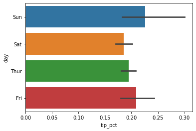

```python
sns.barplot(x='tip_pct', y='day', data=tips, orient='h')
```

- Porcentagem de gorgetas por dia com barras de erro
- As funções de plotagem do seaborn aceitam um argumento *data*, que pode ser um DataFrame do pandas. Os outros argumentos referem-se aos nomes das colunas.
- Como há várias observações para cada valor em *day*, as barras são o valor médio de *tip_pct*.
- As linhas pretas desenhadas nas barras representam o intervalo de confiança de 95%.
- O *seaborn.barplot* tem uma opção *hue* que nos permite fazer uma separação por meio de um valor adicional de categoria.

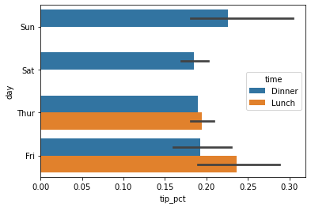

```python
sns.barplot(x='tip_pct', y='day', hue='time', data=tips, orient='h')
```

- Observe que o seaborn alterou automaticamente a estética das plotagens:
  - a paleta de cores default
  - o plano de fundo da plotagem
  - cores das linhas da grade
- Alterando a aparência da plotagem

```python
sns.set(style='whitegrid')
```

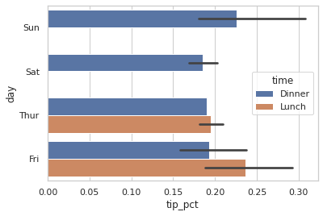

```python
sns.barplot(x='tip_pct', y='day', hue='time', data=tips, orient='h')
```

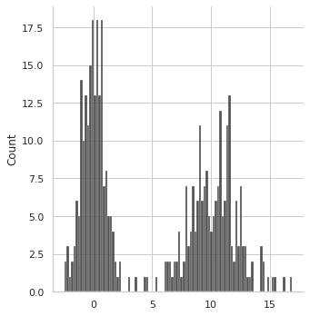

```python
comp1 = np.random.normal(0, 1, size=200)
comp2 = np.random.normal(10, 2, size=200)
values = pd.Series(np.concatenate([comp1, comp2]))

sns.displot(values, bins=100, color='k')
```

- Plotagens de pontos ou de dispesão podem ser uma maneira conveniente de analisar o relacionamento entre duas séries de dados unidimensionais.
- Para exemplificar, carregaremos a seguir o conjunto de dados macrodata, selecionaremos algumas variáveis e então calcularemos as diferenças de log

```python
macro = pd.read_csv('datasets/macrodata.csv')
macro.head(3)
```

|  | year | quarter | realgdp | realcons | realinv | realgovt | realdpi | cpi | m1 | tbilrate | unemp | pop | infl | realint |
| --- | --- | --- | --- | --- | --- | --- | --- | --- | --- | --- | --- | --- | --- | --- |
| 0 | 1959 | 1 | 2710.349 | 1707.4 | 286.898 | 470.045 | 1886.9 | 28.98 | 139.7 | 2.82 | 5.8 | 177.146 | 0.00 | 0.00 |
| 1 | 1959 | 2 | 2778.801 | 1733.7 | 310.859 | 481.301 | 1919.7 | 29.15 | 141.7 | 3.08 | 5.1 | 177.830 | 2.34 | 0.74 |
| 2 | 1959 | 3 | 2775.488 | 1751.8 | 289.226 | 491.260 | 1916.4 | 29.35 | 140.5 | 3.82 | 5.3 | 178.657 | 2.74 | 1.09 |

```python
data = macro[['cpi', 'm1', 'tbilrate', 'unemp']]
trans_data = np.log(data).diff().dropna()
trans_data[-5:]
```

|  | cpi | m1 | tbilrate | unemp |
| --- | --- | --- | --- | --- |
| 198 | -0.007904 | 0.045361 | -0.396881 | 0.105361 |
| 199 | -0.021979 | 0.066753 | -2.277267 | 0.139762 |
| 200 | 0.002340 | 0.010286 | 0.606136 | 0.160343 |
| 201 | 0.008419 | 0.037461 | -0.200671 | 0.127339 |
| 202 | 0.008894 | 0.012202 | -0.405465 | 0.042560 |

- Vamos usar o método *regplot* do *seaborn*, que gera uma plotagem de dispersão e inclui um traço de regressão linear

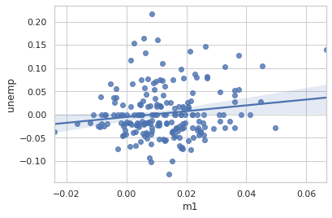

```python
sns.regplot('m1', 'unemp', data=trans_data)
```

- Na análise exploratória de dados, é conveniente observar todas as plotagens de dispersão entre um grupo de variáveis, isso é conhecido como *plotagem de pares* ou uma *matriz de plotagem de dispersão*. Fazer uma plotagem como essa a partir do zero exige um pouco de trabalho.
- O *seaborn* tem uma função *pairplot* conveniente, que aceita colocar histogramas ou estimativas de densidade de cada variável ao longo da diagonal

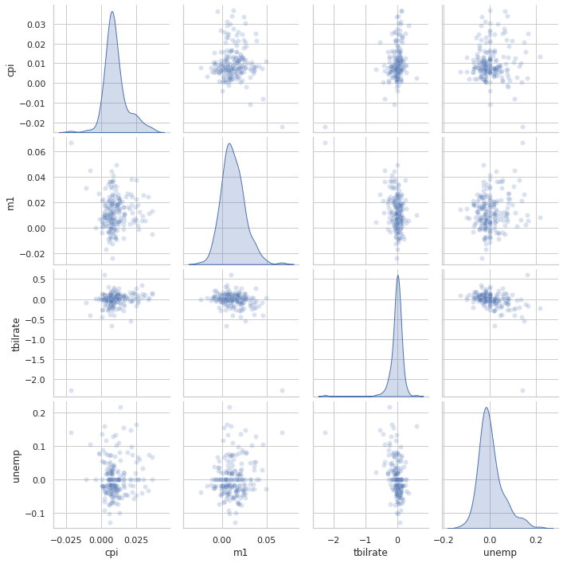

```python
sns.pairplot(trans_data, diag_kind='kde', plot_kws={'alpha':0.2})
```

- O argumento *plot_kws* permite passar opções de configuração para as chamadas de plotagem individuais nos elementos fora da diagonal.
- Uma forma de visualizar dados com muitas variáveis de categoria é por meio de uma *facet grid*. O *seaborn* tem uma função embutida *factorplot* conveniente, que simplifica a criação de vários tipos de plotagem com facetas.
- Vamor criar uma visualização de porcentagem por dia/hora e fumante

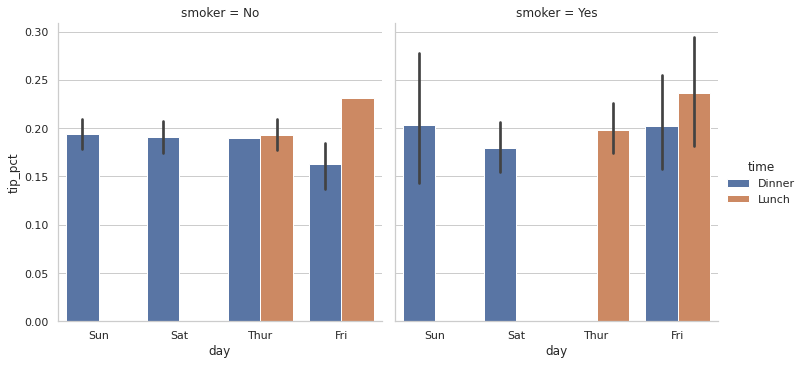

```python
sns.factorplot(x='day', y='tip_pct', hue='time', col='smoker', kind='bar', data=tips[tips.tip_pct < 1])
```

- Podemos também expandir a *facet grid* acrescentando uma linha por valor de *time*

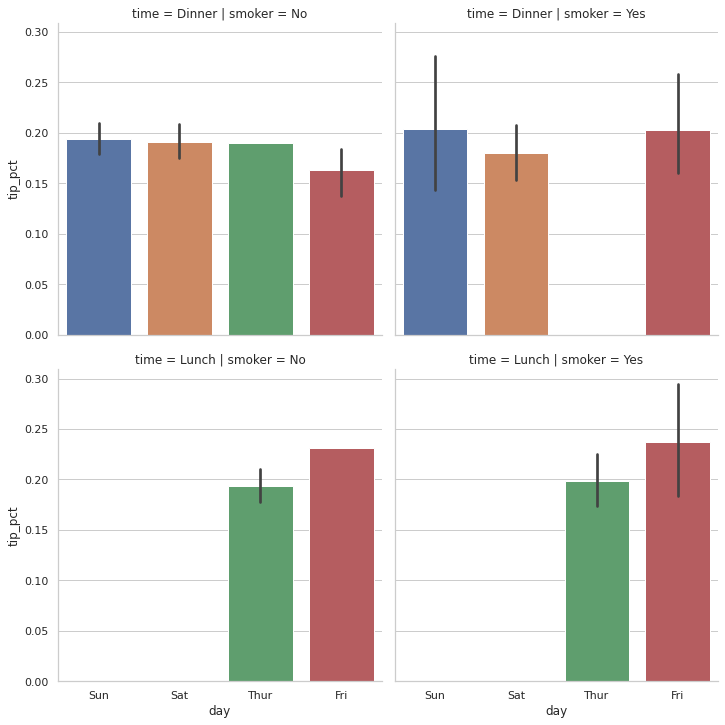

```python
sns.factorplot(x='day', y='tip_pct', row='time', col='smoker', kind='bar', data=tips[tips.tip_pct < 1])
```

- *factorplot* aceita outros tipos de plotagem que podem ser úteis, dependendo do que você estiver tentando exibir.
- Vamos criar uma visualização de *box plot* (que mostram a mediana, os quartis e os valores discrepante).

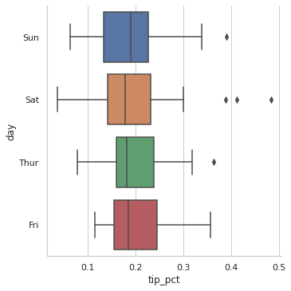

```python
sns.factorplot(x='tip_pct', y='day', kind='box', data=tips[tips.tip_pct < 0.5])
```

- Mais informações: https://seaborn.pydata.org/

### Atividade

- Apresente um histograma com a frequencia de temperatura das lojas do Walmart.

```python
df = pd.read_csv('datasets/Walmart_Store_sales.csv')
df['Date'] = pd.to_datetime(df['Date'], format="%d-%m-%Y")
# df.head(3)
```

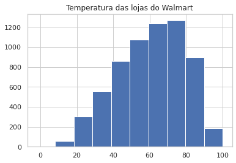

```python
plt.hist(df['Temperature'])
plt.title('Temperatura das lojas do Walmart')
plt.show()
```

- Apresente um gráfico do tipo scatter com as vendas semanais (*Weekly_Sales*) nos feriados das lojas 40 e 45 do Walmart. Adicione marcadores com cores distintas e legendas.

```python
# Filtrando pela loja 40
df_p1 = df[df['Store']==40].loc[(df['Date'] <= datetime(2010,12,31)) & (df['Holiday_Flag']==1)]
df_p1 = df_p1[['Date', 'Weekly_Sales']]
df_p1.set_index("Date",inplace=True)
# df_p1
```

```python
# Filtrando pela loja 45
df_p2 = df[df['Store']==45].loc[(df['Date'] <= datetime(2010,12,31)) & (df['Holiday_Flag']==1)]
df_p2 = df_p2[['Date', 'Weekly_Sales']]
df_p2.set_index("Date",inplace=True)
# df_p2
```

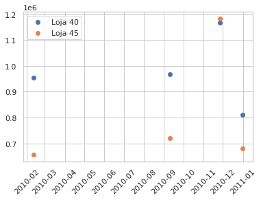

```python
plt.scatter(df_p1.index, df_p1['Weekly_Sales'], label='Loja 40')
plt.scatter(df_p2.index, df_p2['Weekly_Sales'], label='Loja 45')
plt.legend()
plt.xticks(rotation=45)
plt.show()
```

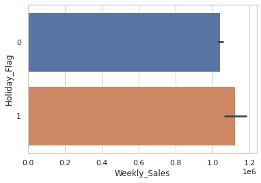

```python
sns.barplot(x='Weekly_Sales', y='Holiday_Flag', data=df, orient='h')
```